# test

## 👋Uvod - Priprema podataka

Zadatak je pred nama i ne želimo odugovlačiti. Krećemo odmah sa uvoženjem biblioteka i čitanjem podataka:

```python
import pandas as pd
import matplotlib.pyplot as plt
import seaborn as sns

df = pd.read_csv("online_store_data.csv")
```

## ⚡Brzi pregled

Izvršićemo jedan ispis podataka na brzinu kako bismo imali kratak uvid sa kakvim podacima radimo:

```python
df.head()
```

|  | product_name | category | price | quantity_in_stock | quantity_sold | brand | rating | num_of_ratings | date_added | color | revenue |
| --- | --- | --- | --- | --- | --- | --- | --- | --- | --- | --- | --- |
| 0 | iPad mini (2021) (64GB, Blue) | Tablets | 499.00 | 266.0 | 807.0 | Apple | 8.75 | 151.0 | 2/2/2022 | blue | 402693.00 |
| 1 | K55 RGB (Red) | Keyboards | 49.99 | 0.0 | 1117.0 | Corsair | 8.50 | 455.0 | 8/14/2022 | red | 55838.83 |
| 2 | Fenix 7 (Purple) | Watches | 699.99 | 0.0 | 530.0 | Garmin | 9.20 | 305.0 | 4/20/2022 | purple | 370994.70 |
| 3 | Mate 40 (256GB, Orange) | Smartphones | 899.00 | 182.0 | 1030.0 | Huawei | 8.50 | 500.0 | 10/23/2024 | orange | 925970.00 |
| 4 | Rival 600 (Red) | Mice | 79.99 | 35.0 | 1439.0 | SteelSeries | 9.25 | 556.0 | 9/29/2020 | red | 115105.61 |

## 1️⃣Prva analiza - Distribucija broja prodatih jedinica

Možemo krenuti sa analizama. Prvo želimo da vidimo kako su proizvodi raspoređeni po broju prodatih jedinica:

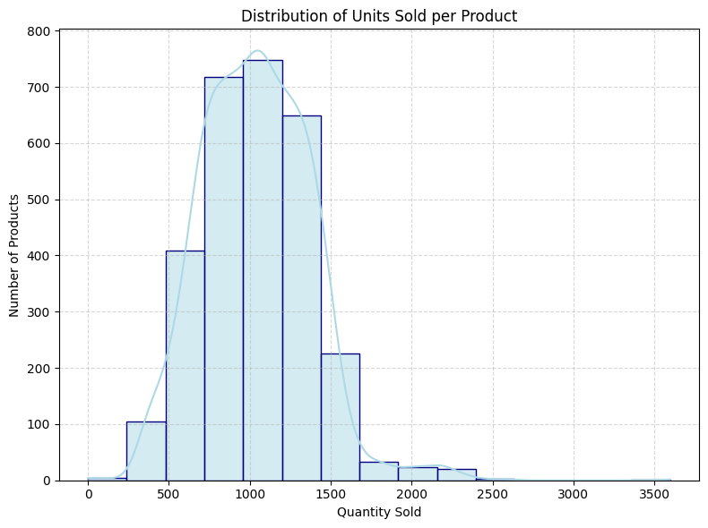

```python
plt.figure(figsize=(8,6))
sns.histplot(df["quantity_sold"], bins=15, kde=True, color='lightblue', edgecolor='navy')
plt.title("Distribution of Units Sold per Product")
plt.xlabel("Quantity Sold")
plt.ylabel("Number of Products")
plt.grid(True, linestyle="--", alpha=0.5)
plt.tight_layout()
plt.show()
```

## 💬Komentar:

Histogram nam pokazuje širu sliku, za detalje nam je potreban drugačiji dijagram - **kutijasti**

Prikazaćemo istu analizu preko kutijastog da bismo još detaljnije odradili analizu:

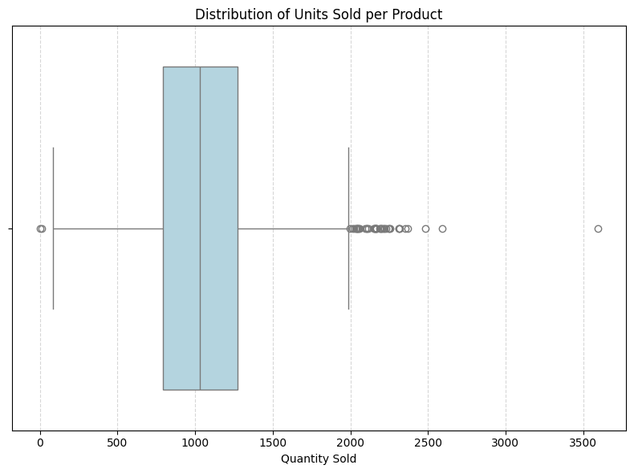

```python
plt.figure(figsize=(8,6))
sns.boxplot(data=df, x="quantity_sold", color='lightblue')
plt.title("Distribution of Units Sold per Product")
plt.xlabel("Quantity Sold")
plt.grid(True, axis="x", linestyle="--", alpha=0.5)
plt.tight_layout()
plt.show()
```

## 2️⃣ Druga analiza - Upoređivanje kategorija

Želimo da vidimo kako se prodaja razlikuje među **kategorijama proizvoda** - kutijasti dijagram opet stupa na scenu:

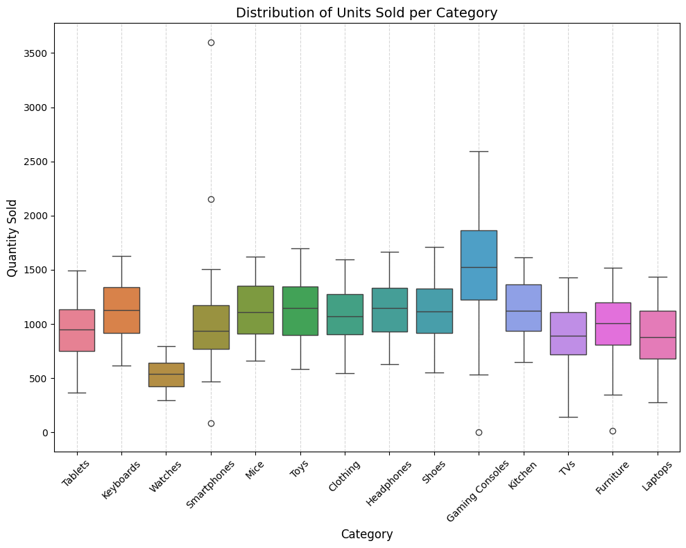

```python
plt.figure(figsize=(10,8))
sns.boxplot(data=df, x="category", y="quantity_sold", hue='category')
plt.title("Distribution of Units Sold per Category", fontsize=14)
plt.xlabel("Category", fontsize=12)
plt.ylabel("Quantity Sold", fontsize=12)
plt.xticks(rotation=45)
plt.grid(True, axis="x", linestyle="--", alpha=0.5)
plt.tight_layout()
plt.show()
```

## Treća analiza - Korelacija

Želimo da analizaramo kako su numeričke karakteristike povezane sa prodajom - pomoći će nam **toplotna mapa**:

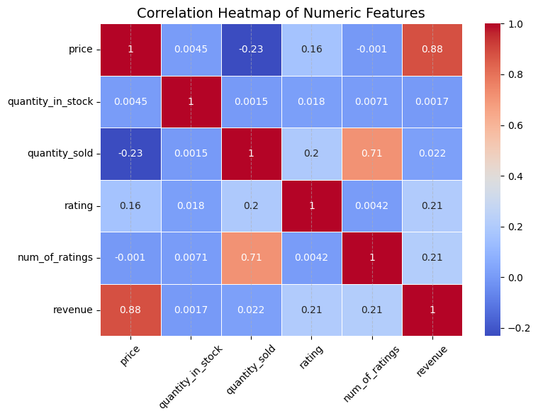

```python
numeric_df = df.select_dtypes(include='number')
corr_matrix = numeric_df.corr()
plt.figure(figsize=(8,6))
sns.heatmap(data=corr_matrix, annot=True, cmap='coolwarm', linewidths=0.5)
plt.title("Correlation Heatmap of Numeric Features", fontsize=14)
plt.xticks(rotation=45)
plt.grid(True, axis="x", linestyle="--", alpha=0.5)
plt.tight_layout()
plt.show()
```